# mirror.barplot - mirrored barplot for comparing positive and negative changes in a variable

The code for this function can be found here.

The arguments to pass to the function are:

- `lower.vals` - A `numeric` vector or a column of a `matrix` or `data.frame`
- `upper.vals` - A `numeric` vector or a column of a `matrix` or `data.frame`
- `cols` - A `character` vector of length 2 corresponding to the colors for the upper and lower values respectively
- `bar.width` - `numeric` value for width of the bars
- `bar.spacing` - `numeric` value for the amount of space between bars
- `upper.y.text` - A `character` or `expression` to be plotted next to the upper values
- `lower.y.text` - A `character` or `expression` to be plotted next to the lower values
- `y.lab.offset` - `numeric` value for the y label offset
- `y.lab.cex` - `numeric` size of the y label
- `margins` - `numeric` vector for plotting margins

To demonstrate this function I will use data comparing the climatic conditions of invasive ranges of species to that of their native ranges (N. Crouch, *unpublished data*)

```r
# The function
source("mirror.barplot.R")

# The data
dat <- read.csv("analysis_data.csv")
```

I will first calculate whether the temperature of the invasive ranges exceeds that of the native ranges

```r
# Lower minimum temperature in invasive range
tMin <- dat$Native_Temp_Min - dat$Invasive_Temp_Min
tMin[tMin < 0] <- 0
dat$TempMinIncrease <- tMin

# Higher maximum temperature in invasive range
tMax <- dat$Invasive_Temp_Max - dat$Native_Temp_Max
tMax[tMax < 0] <- 0
dat$TempMaxIncrease <- tMax
```

Now the plot can be generated:

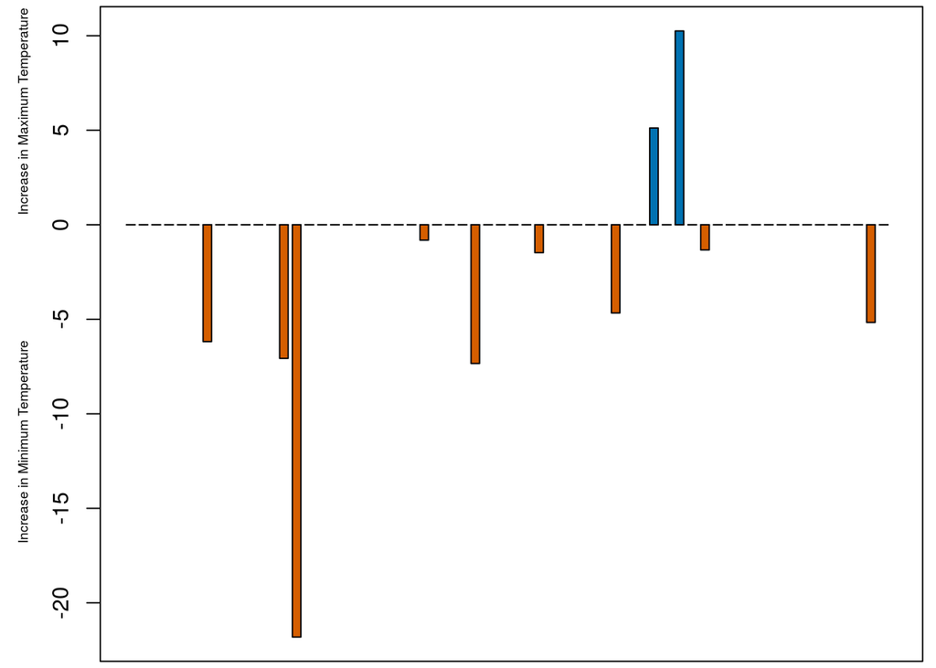

```r
mirror.barplot(lower.vals = dat$TempMinIncrease, upper.vals = dat$TempMaxIncrease, upper.y.text = "Increase in Maximum Temperature", lower.y.text = "Increase in Minimum Temperature", cols=c("#0072B2", "#D55E00"), margins=c(0.05,0.75,0.05,0.1), y.lab.cex=0.6)
```